# L8_z2_1

## Zadanie 2 - słownik

- Zaimplementuj metodę generującą drzewo przeszukiwania binarnego na podstawie struktury robotówz wcześniejszych list.Kluczowy parametr struktury (parametr robota, względem którego tworzone jest drzewo) zadaje użytkownik. Zaimplementuj efektywne algorytmy:
  - przechodzenia drzewa metodami inorder, preorder i postorder,
  - wyszukiwania elementu (i ścieżki prowadzącej do tego elementu, zaczynając od korzenia),
  - wyszukiwania minimum i maksimum,
  - wyszukiwania następnika i poprzednika zadanego węzła,
  - wstawiania i usuwania węzła.

```python
import networkx as nx
#from L6_0_data_structure import create_m_bots
import matplotlib.pyplot as plt
```

```python
class Node:
    def __init__(self, value, params, left=None, right=None):
        self.value = value
        self.params = params
        self.left = left
        self.right = right

    def add_left(self, value):
        self.left = Node(value)

    def add_left(self, value):
        self.right = Node(value)

    def print_graph(self):
        if self.left:
            self.left.print_graph()
        print(self.value),
        if self.right:
            self.right.print_graph()

    def inorder_traversal(self, root):
        res = []

        if root:
            res = self.inorder_traversal(root.left)
            res.append(root.value)
            res += res + self.inorder_traversal(root.right)
        return res
```

```python
def create_bst(vector):
    """
    Funkcja tworzy drzewo przeszukiwania binarnego na podanym wektorze
    :param list vector: tablica liczb - które staną się wirzchołkami
    :return list tree_nodes: list wierzchołków drzewa
    """
    tree_nodes = []
    root = Node(vector.pop(0))
    tree_nodes.append(root)

    for n in vector:

        temp_root = root


        while True:

            if n > temp_root.value: #w BST prawe dziecko ma wieksa wartosc
                # idziemy do prawej części drzewa

                if temp_root.right == None:
                    node = Node(n)
                    temp_root.right = node
                    tree_nodes.append(node)
                    break

                else:
                    temp_root = temp_root.right

            elif n <= temp_root.value: #lewe dziecko ma miec mniejsza wartosc od rodzica
                #idziemy do lewej części drzewa

                if temp_root.left == None:
                    node = Node(n)
                    temp_root.left = node
                    tree_nodes.append(node)
                    break

                else:
                    temp_root = temp_root.left

    return tree_nodes
```

```python
def array_to_tree(arr, f):
    """
    Funkcja tworząca zrównowarzone drzewo binarne z posortowanej listy wierzchołków
    :param list arr: posortowana lista wierzchołków
    :param f: główna cecha która świadczy o wartości węzła
    :return object root: objekt klasy Node - korzeń grafu
    """
    if not arr:
        return None

    mid = (len(arr)) // 2


    # przypisanie środkowego elementu jako węzła drzewa
    root = Node(arr[mid][f], arr[mid])

    # podział listy na pół
    root.left = array_to_tree(arr[:mid], f)
    root.right = array_to_tree(arr[mid+1:], f)

    return root
```

```python
def get_edges(root):
    edges = []
    if root.left:
        edges += get_edges(root.left)
        edges.append((root.value, root.left.value))

    if root.right:
        edges += get_edges(root.right)
        edges.append((root.value, root.right.value))

    return edges


def visualiz_graph(root):
    """
    Funkcja tworząca wykres drzewa
    :param root: korzeń - węzeł od którego zaczynamy tworzyć drzewo
    """
    nodes = []
    edges = get_edges(root)

    for item in edges:
        if item[0] not in nodes:
            nodes.append(item[0])
        if item[1] not in nodes:
            nodes.append(item[1])

    g = nx.Graph()
    colors = ['red' if n == root.value else 'orange' for n in nodes]

    g.add_nodes_from(nodes)
    g.add_edges_from(edges)
    pos = hierarchy_pos(g, root.value)
    nx.draw(g, pos, node_color=colors)
    nx.draw_networkx_labels(g, pos=pos)
    plt.show()
```

```python
# generownie wektora robotów
#bots = create_m_bots(15)
#bots = [b.save_robot() for b in bots]
bots = [{'id': '1101', 'typ': 'WUU', 'masa': 1219, 'roz': 26},
 {'id': '0000', 'typ': 'VNN', 'masa': 1745, 'roz': 9},
 {'id': '1110', 'typ': 'GVV', 'masa': 131, 'roz': 24},
 {'id': '1011', 'typ': 'NAV', 'masa': 758, 'roz': 29},
 {'id': '1000', 'typ': 'NGW', 'masa': 96, 'roz': 11},
 {'id': '0111', 'typ': 'CNN', 'masa': 1217, 'roz': 13},
 {'id': '0000', 'typ': 'UAG', 'masa': 762, 'roz': 27},
 {'id': '1000', 'typ': 'VCU', 'masa': 1833, 'roz': 17},
 {'id': '0100', 'typ': 'GUA', 'masa': 544, 'roz': 24},
 {'id': '0011', 'typ': 'VWN', 'masa': 1008, 'roz': 25},
 {'id': '1101', 'typ': 'CUG', 'masa': 871, 'roz': 1},
 {'id': '1110', 'typ': 'AVU', 'masa': 359, 'roz': 21},
 {'id': '0101', 'typ': 'ANV', 'masa': 1471, 'roz': 16},
 {'id': '1011', 'typ': 'UCN', 'masa': 1025, 'roz': 18},
 {'id': '1100', 'typ': 'WNA', 'masa': 1762, 'roz': 7}]
```

# Pierwszy podpunkt

Zaimplementuj metodę generującą drzewo przeszukiwania binarnego na podstawie struktury robotów z wcześniejszych list. Kluczowy parametr struktury (parametr robota, względem którego tworzone jest drzewo) zadaje użytkownik.

```python
# wybranie cechy przez użytkownika
#feat = input('Podaj cechę: ')
feat = 'masa'
feat
bots = sorted(bots, key=lambda x: x['masa'])
"""vec = [b[feat] for b in bots]
vec.sort()"""
ROOT = array_to_tree(bots, feat)
ROOT
```

```
<__main__.Node at 0x2a3fc2728b0>
```

```python
visualiz_graph(ROOT)
```

[output not shown]

## Przechodznie metodą in-order

Najpierw przechodzimy lewe poddrzewo danego węzła, następnie odwiedzamy węzeł i na koniec przechodzimy prawe poddrzewo

lewy - korzeń - prawy

```python
def inorder_traversal(root):
    # left - root - right
    path = []

    if root:

        path += inorder_traversal(root.left)
        path.append(root.value)

        path += inorder_traversal(root.right)

    return path

print(inorder_traversal(ROOT))
```

```
[96, 131, 359, 544, 758, 762, 871, 1008, 1025, 1217, 1219, 1471, 1745, 1762, 1833]
```

```python
visualiz_graph(ROOT)
```

[output not shown]

## Przechodzenie drzewa metodą preorder

Najpierw odwiedzamy korzeń poddrzewa, a następnie przechodzimy kolejne lewe i prawe poddrzewo

korzeń - lewy - prawy

```python
def preorder(root):
    path = []

    if root:
        path.append(root.value)
        path += preorder(root.left)
        path += preorder(root.right)

    return path

print(preorder(ROOT))
visualiz_graph(ROOT)
```

[output not shown]

```
[1008, 544, 131, 96, 359, 762, 758, 871, 1471, 1217, 1025, 1219, 1762, 1745, 1833]
```

## Przechodznie drzewa metodą postorder

Najpierw przechodzimy lewe poddrzewo, następnie prawe, a dopiero na końcu przetwazamy węzeł

lewy - prawy - korzeń

```python
def post_order(root):
    path = []

    if root:
        path += post_order(root.left)
        path += post_order(root.right)
        path.append(root.value)

    return path


print(post_order(ROOT))
```

```
[96, 359, 131, 758, 871, 762, 544, 1025, 1219, 1217, 1745, 1833, 1762, 1471, 1008]
```

```python
visualiz_graph(ROOT)
```

[output not shown]

## Wyszukiwanie elementu

```python
def find_node(root, value):
    if not root:
        return None
    if value == root.value:
        return root

    if value < root.value:
        return find_node(root.left, value)

    if value > root.value:
        return find_node(root.right, value)


node = find_node(ROOT, 1217)
print(node.params)
```

```
{'id': '0111', 'typ': 'CNN', 'masa': 1217, 'roz': 13}
```

## Wyszukiwanie minimum i maksimum

```python
def find_max(root):
    if root.right:
        return find_max(root.right)
    elif root.left:
        return root.left
    else:
        return root

def find_min(root):
    if root.left:
        return find_min(root.left)
    elif root.right:
        return root.right
    else:
        return root

print('MIN', find_min(ROOT).params)
print('MAX', find_max(ROOT).params)
```

```
MIN {'id': '1000', 'typ': 'NGW', 'masa': 96, 'roz': 11}
MAX {'id': '1000', 'typ': 'VCU', 'masa': 1833, 'roz': 17}
```

## Wyszukiwania następnika i poprzednika zadanego węzła

Następnik danego węzła jest węzłem, który jest odwiedzany jako następny w przypadku przechodzenia drzewa metodą in-order.

```python
def find_succesor(root, node): #następca
    # Step 1 of the above algorithm
    if node.right is not None:
        return find_min(node.right)

    # Step 2 of the above algorithm
    succ=Node(None)


    while(root):
        if(root.data < node.data):
            root=root.right
        elif(root.data > node.data):
            succ=root
            root=root.left
        else:
            break
    return succ


def find_predcessor(root, value, prec=None): #poprzednik

    # przypadek podstawowy
    if root is None:
        return prec

    if root.value == value:
        if root.left:
            return find_max(root.left)

    elif value < root.value:
        return find_predcessor(root.left, value, prec)

    else:
        prec = root
        return find_predcessor(root.right, value, prec)

    return prec


n = find_node(ROOT, 1217)
print(n.params)
print(find_succesor(ROOT, n).params)
print(find_predcessor(ROOT, 1217, None).params)
```

```
{'id': '0111', 'typ': 'CNN', 'masa': 1217, 'roz': 13}
{'id': '1101', 'typ': 'WUU', 'masa': 1219, 'roz': 26}
{'id': '1011', 'typ': 'UCN', 'masa': 1025, 'roz': 18}
```

## Wstawiania i usuwania węzła

```python
def insert_node(root, value, params):
    # sprawdznie czy drzewo nie jest puste
    if root == None:
        return Node(value, params)
    else:
        if value <= root.value:
            # idzemy na lewo
            temp = insert_node(root.left, value, params)
            root.left = temp

        else:
            # idziemy na prowo
            temp = insert_node(root.right, value, params)
            root.right = temp

    return root

v = 1000
insert_node(ROOT, v, {'id': '1110', 'typ': 'VVW', 'masa': v, 'roz': 20})
```

```
<__main__.Node at 0x2a3fc2728b0>
```

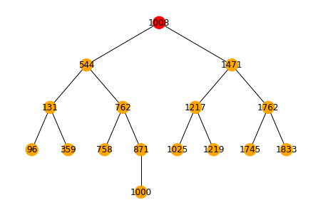

```python
visualiz_graph(ROOT)
```

```python
def delete_node(root, value):
    # if root doesn't exist, just return it
    if not root:
        return root
    # Find the node in the left subtree	if key value is less than root value
    if root.value > value:
        root.left = delete_node(root.left, value)
    # Find the node in right subtree if key value is greater than root value,
    elif root.value < value:
        root.right= delete_node(root.right, value)
    # Delete the node if root.value == key
    else:
    # If there is no right children delete the node and new root would be root.left
        if not root.right:
            return root.left
    # If there is no left children delete the node and new root would be root.right
        if not root.left:
            return root.right
# If both left and right children exist in the node replace its value with
# the minmimum value in the right subtree. Now delete that minimum node
# in the right subtree
        temp_val = root.right
        mini_val = temp_val.value
        while temp_val.left:
            temp_val = temp_val.left
            mini_val = temp_val.value
# Delete the minimum node in right subtree
        root.right = delete_node(root.right, root.value)
    return root


delete_node(ROOT, 1000)
```

```
<__main__.Node at 0x2a3fc2728b0>
```

```python
visualiz_graph(ROOT)
```

[output not shown]

```python
# Komórka do resetowania drzewa
ROOT = array_to_tree(bots, feat)
visualiz_graph(ROOT)
```

[output not shown]

```python
import networkx as nx
import random


def hierarchy_pos(G, root=None, width=1., vert_gap = 0.2, vert_loc = 0, xcenter = 0.5):

    '''
    From Joel's answer at https://stackoverflow.com/a/29597209/2966723.
    Licensed under Creative Commons Attribution-Share Alike

    If the graph is a tree this will return the positions to plot this in a
    hierarchical layout.

    G: the graph (must be a tree)

    root: the root node of current branch
    - if the tree is directed and this is not given,
      the root will be found and used
    - if the tree is directed and this is given, then
      the positions will be just for the descendants of this node.
    - if the tree is undirected and not given,
      then a random choice will be used.

    width: horizontal space allocated for this branch - avoids overlap with other branches

    vert_gap: gap between levels of hierarchy

    vert_loc: vertical location of root

    xcenter: horizontal location of root
    '''
    if not nx.is_tree(G):
        raise TypeError('cannot use hierarchy_pos on a graph that is not a tree')

    if root is None:
        if isinstance(G, nx.DiGraph):
            root = next(iter(nx.topological_sort(G)))  #allows back compatibility with nx version 1.11
        else:
            root = random.choice(list(G.nodes))

    def _hierarchy_pos(G, root, width=1., vert_gap = 0.2, vert_loc = 0, xcenter = 0.5, pos = None, parent = None):
        '''
        see hierarchy_pos docstring for most arguments

        pos: a dict saying where all nodes go if they have been assigned
        parent: parent of this branch. - only affects it if non-directed

        '''

        if pos is None:
            pos = {root:(xcenter,vert_loc)}
        else:
            pos[root] = (xcenter, vert_loc)
        children = list(G.neighbors(root))
        if not isinstance(G, nx.DiGraph) and parent is not None:
            children.remove(parent)
        if len(children)!=0:
            dx = width/len(children)
            nextx = xcenter - width/2 - dx/2
            for child in children:
                nextx += dx
                pos = _hierarchy_pos(G,child, width = dx, vert_gap = vert_gap,
                                    vert_loc = vert_loc-vert_gap, xcenter=nextx,
                                    pos=pos, parent = root)
        return pos


    return _hierarchy_pos(G, root, width, vert_gap, vert_loc, xcenter)
```